# Machine Learning I: Assessment (1/2)

Konstantinos Lessis, Maurice Willen, Nico Wyss, Sothy Yogarajah

Document created on 11.06.2020

# 1 Initial Situation

Due to the size of the project we decided to create two documents:

- group_work_classification, IBM telco data set
- group_work_regression, bike sharing data set

**Classification models with the IBM telco data set**

Part of this document are the classification models. We decided to use the IBM telco customer churn analysis data set from Github for for this purpose.

Data Source: https://github.com/IBM/telco-customer-churn-on-icp4d

We are using EDA to find the most promising predictors and later on use them for our predictive modelling techniques to determine if customers are most likely to churn.

Target variable: churn

the customer churn column tells us if the customer has left within the last month.

Models in use and comparison: * Support Vector Machine * Random Forest * Logistic Regression * Artificial Neural Networks

# 2 Start Setup Options

```r
# clear workspace
rm(list = ls(all.names = TRUE))
# garbage collection
gc()
```

```
          used  (Mb) gc trigger  (Mb) max used  (Mb)
Ncells 3676395 196.4    6547094 349.7  6547094 349.7
Vcells 8204235  62.6   28793169 219.7 37405519 285.4
```

```r
# penalty for exponential notation
options(scipen = 999)
# significant digits after komma
options(digits = 4)

# condition to check if packetmanager pacman is installed and install
if ("pacman" %in% rownames(installed.packages()) == TRUE) {
  library(pacman)
} else {
  install.packages("pacman")
  library(pacman)
}

# load packages and install them if not installed
p_load(tidyverse, tidymodels, janitor, here, corrr, skimr, ggthemes)
p_load(kernlab, randomForest)
p_load(viridis)
```

Package Discription:

| Package | Description |
| --- | --- |
| **Tidyverse** | The tidyverse is an opinionated collection of R packages designed for data science. All packages share an underlying design philosophy, grammar, and data structures. |
| **Tidymodels** | The tidymodels framework is a collection of packages for modeling and machine learning using tidyverse principles. |
| **janitor** | This function is powered by the underlying exported function make_clean_names(), which accepts and returns a character vector of names. This allows for cleaning the names (head of columns) of any obje… |
| **corrr** | A tool for exploring correlations. It makes it possible to easily perform routine tasks when exploring correlation matrices such as ignoring the diagonal, focusing on the correlations of certain varia… |
| **skimr** | A simple to use summary function that can be used with pipes and displays nicely in the console. The default summary statistics may be modified by the user as can the default formatting. Support for d… |
| **ggthemes** | Some extra themes, geoms, and scales for ‘ggplot2’. Provides ‘ggplot2’ themes and scales that replicate the look of plots by Edward Tufte, Stephen Few, ‘Fivethirtyeight’, ‘Tableau’, ‘The Economist’, ‘… |

# 3 Importing Data

```r
df_ibm <- read_csv(here("data", "ibm.csv"))
```

# 4 Exploratory Data Analysis

## 4.1 Summary Statistics

```r
skim(df_ibm)
```

```
── Data Summary ────────────────────────
                           Values
Name                       df_ibm
Number of rows             7043
Number of columns          21
_______________________
Column type frequency:
  character                17
  numeric                  4
________________________
Group variables            None

── Variable type: character ─────────────────────────────────────────────────────────
   skim_variable    n_missing complete_rate   min   max empty n_unique whitespace
 1 customerID               0             1    10    10     0     7043          0
 2 gender                   0             1     4     6     0        2          0
 3 Partner                  0             1     2     3     0        2          0
 4 Dependents               0             1     2     3     0        2          0
 5 PhoneService             0             1     2     3     0        2          0
 6 MultipleLines            0             1     2    16     0        3          0
 7 InternetService          0             1     2    11     0        3          0
 8 OnlineSecurity           0             1     2    19     0        3          0
 9 OnlineBackup             0             1     2    19     0        3          0
10 DeviceProtection         0             1     2    19     0        3          0
11 TechSupport              0             1     2    19     0        3          0
12 StreamingTV              0             1     2    19     0        3          0
13 StreamingMovies          0             1     2    19     0        3          0
14 Contract                 0             1     8    14     0        3          0
15 PaperlessBilling         0             1     2     3     0        2          0
16 PaymentMethod            0             1    12    25     0        4          0
17 Churn                    0             1     2     3     0        2          0

── Variable type: numeric ───────────────────────────────────────────────────────────
  skim_variable  n_missing complete_rate     mean       sd    p0   p25    p50    p75
1 SeniorCitizen          0         1        0.162    0.369   0     0      0      0
2 tenure                 0         1       32.4     24.6     0     9     29     55
3 MonthlyCharges         0         1       64.8     30.1    18.2  35.5   70.4   89.8
4 TotalCharges          11         0.998 2283.    2267.     18.8 401.  1397.  3795.
   p100 hist
1    1  ▇▁▁▁▂
2   72  ▇▃▃▃▆
3  119. ▇▅▆▇▅
4 8685. ▇▂▂▂▁
```

There are 7043 observations with 21 different variables. There are only 11 NAs in the whole data set. That’s only 0.16% of the total number of observations.

There are 3 continuous variables: * Tenure * Monthly Charges * Total Charges

And one wrongly formatted variable: * Senior Citizen (formatted as integer)

## 4.2 Data Cleansing

```r
df_ibm <- df_ibm %>%
  clean_names(case = "snake") %>%
  mutate(senior_citizen = ifelse(senior_citizen == 1, "Yes", "No"))

df_ibm %>% skim()
```

```
── Data Summary ────────────────────────
                           Values
Name                       Piped data
Number of rows             7043
Number of columns          21
_______________________
Column type frequency:
  character                18
  numeric                  3
________________________
Group variables            None

── Variable type: character ─────────────────────────────────────────────────────────
   skim_variable     n_missing complete_rate   min   max empty n_unique whitespace
 1 customer_id               0             1    10    10     0     7043          0
 2 gender                    0             1     4     6     0        2          0
 3 senior_citizen            0             1     2     3     0        2          0
 4 partner                   0             1     2     3     0        2          0
 5 dependents                0             1     2     3     0        2          0
 6 phone_service             0             1     2     3     0        2          0
 7 multiple_lines            0             1     2    16     0        3          0
 8 internet_service          0             1     2    11     0        3          0
 9 online_security           0             1     2    19     0        3          0
10 online_backup             0             1     2    19     0        3          0
11 device_protection         0             1     2    19     0        3          0
12 tech_support              0             1     2    19     0        3          0
13 streaming_tv              0             1     2    19     0        3          0
14 streaming_movies          0             1     2    19     0        3          0
15 contract                  0             1     8    14     0        3          0
16 paperless_billing         0             1     2     3     0        2          0
17 payment_method            0             1    12    25     0        4          0
18 churn                     0             1     2     3     0        2          0

── Variable type: numeric ───────────────────────────────────────────────────────────
  skim_variable   n_missing complete_rate   mean     sd    p0   p25    p50    p75
1 tenure                  0         1       32.4   24.6   0     9     29     55
2 monthly_charges         0         1       64.8   30.1  18.2  35.5   70.4   89.8
3 total_charges          11         0.998 2283.  2267.   18.8 401.  1397.  3795.
   p100 hist
1   72  ▇▃▃▃▆
2  119. ▇▅▆▇▅
3 8685. ▇▂▂▂▁
```

We are type correcting Senior Citizen and unifying column names to snake case.

## 4.3 Categorical Variables

### 4.3.1 Gender, Senior Citizen, Partner

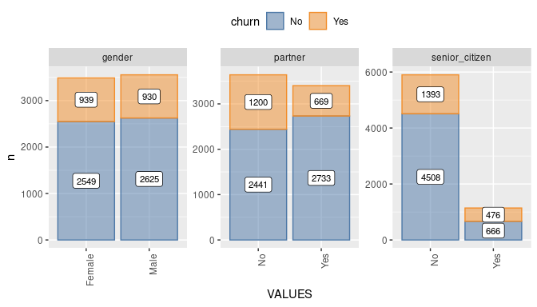

```r
# vector with the name of nominal variables to plot
vec_variable <- c("gender", "senior_citizen", "partner")

df_ibm %>%
  select(churn, one_of(vec_variable)) %>%
  select_if(is.character) %>%
  pivot_longer(names_to  = "VARIABLES",
               values_to = "VALUES",
               cols      =  one_of(vec_variable)) %>%
  count(churn, VARIABLES, VALUES) %>%
  ggplot() +
  geom_bar(position = position_stack(reverse = TRUE),
           stat = "identity",
           aes(x = VALUES, y = n, fill = churn, color = churn), alpha = 0.5) +
  theme(axis.text.x = element_text(angle = 90, hjust = 1), legend.position = "top") +
  facet_wrap(~ VARIABLES, ncol = 4, scales = "free") +
  scale_color_tableau() +
  scale_fill_tableau() +
  scale_x_discrete() +
  geom_label(aes(x = VALUES, y = n, label = n),
            position = position_stack(vjust = 0.5),
            size = 3)
```

```r
rm(vec_variable)
```

- Gender: churn is almost equal in case of males and females. Gender might not be a determining factor
- Partner: customer with partner has lower churn rate, since two people might be affected from the changes, you’ll endure higher bill rate longer.
- Senior Citizen: churn is higher if it is a senior citizen

### 4.3.2 Phone Service, Multiple Lines, Internet Service

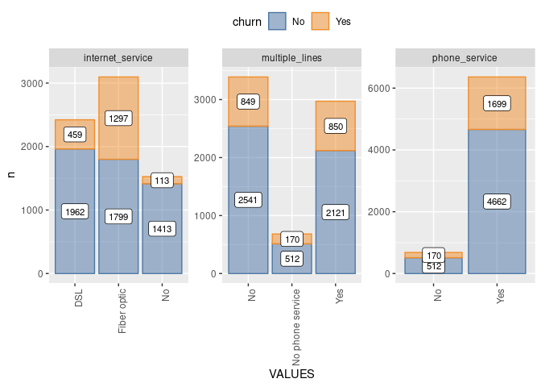

```r
# vector with the name of nominal variables to plot
vec_variable <- c("phone_service", "multiple_lines", "internet_service")

df_ibm %>%
  select(churn, one_of(vec_variable)) %>%
  select_if(is.character) %>%
  pivot_longer(names_to  = "VARIABLES",
               values_to = "VALUES",
               cols      =  one_of(vec_variable)) %>%
  count(churn, VARIABLES, VALUES) %>%
  ggplot() +
  geom_bar(position = position_stack(reverse = TRUE),
           stat = "identity",
           aes(x = VALUES, y = n, fill = churn, color = churn), alpha = 0.5) +
  theme(axis.text.x = element_text(angle = 90, hjust = 1),
        legend.position = "top") +
  facet_wrap(~ VARIABLES, ncol = 4, scales = "free") +
  scale_color_tableau() +
  scale_fill_tableau() +
  scale_x_discrete() +
  geom_label(aes(x = VALUES, y = n, label = n),
            position = position_stack(vjust = 0.5),
            size = 3)
```

```r
rm(vec_variable)
```

- Phone Service: churn around the same
- Multiple Lines: churn is slightly higher if multiple lines are used
- Internet Service: Churn rate is much higher in case of fiber optic (lower switching costs?)

### 4.3.3 Online Security, Online Backup, Tech Support

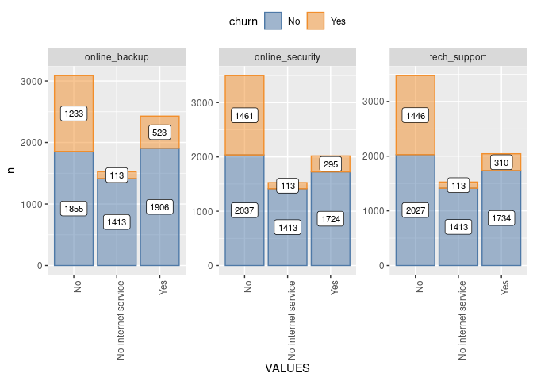

```r
# vector with the name of nominal variables to plot
vec_variable <- c("online_security", "online_backup", "tech_support")

df_ibm %>%
  select(churn, one_of(vec_variable)) %>%
  select_if(is.character) %>%
  pivot_longer(names_to  = "VARIABLES",
               values_to = "VALUES",
               cols      =  one_of(vec_variable)) %>%
  count(churn, VARIABLES, VALUES) %>%
  ggplot() +
  geom_bar(position = position_stack(reverse = TRUE),
           stat = "identity",
           aes(x = VALUES, y = n, fill = churn, color = churn), alpha = 0.5) +
  theme(axis.text.x = element_text(angle = 90, hjust = 1),
        legend.position = "top") +
  facet_wrap(~ VARIABLES, ncol = 4, scales = "free") +
  scale_color_tableau() +
  scale_fill_tableau() +
  scale_x_discrete() +
  geom_label(aes(x = VALUES, y = n, label = n),
            position = position_stack(vjust = 0.5),
            size = 3)
```

```r
rm(vec_variable)
```

- Online Security: Customer without are with higher churn rate
- Online Backup: Customer without are with higher churn rate
- Tech Support: Customer without are with higher churn rate

### 4.3.4 Streaming Movies, Streaming TV, Contract

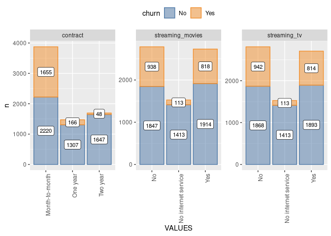

```r
# vector with the name of nominal variables to plot
vec_variable <- c("streaming_movies", "streaming_tv", "contract")

df_ibm %>%
  select(churn, one_of(vec_variable)) %>%
  select_if(is.character) %>%
  pivot_longer(names_to  = "VARIABLES",
               values_to = "VALUES",
               cols      =  one_of(vec_variable)) %>%
  count(churn, VARIABLES, VALUES) %>%
  ggplot() +
  geom_bar(position = position_stack(reverse = TRUE),
           stat = "identity",
           aes(x = VALUES, y = n, fill = churn, color = churn), alpha = 0.5) +
  theme(axis.text.x = element_text(angle = 90, hjust = 1),
        legend.position = "top") +
  facet_wrap(~ VARIABLES, ncol = 4, scales = "free") +
  scale_color_tableau() +
  scale_fill_tableau() +
  scale_x_discrete() +
  geom_label(aes(x = VALUES, y = n, label = n),
            position = position_stack(vjust = 0.5),
            size = 3)
```

```r
rm(vec_variable)
```

- Contract: Higher churn rate with month-to-month payment
- Streaming Movies: churn rate is lowest if no internet service
- Streaming TV: churn rate is lowest if no internet service

### 4.3.5 Device Protection, Paperless Billing, Payment Method

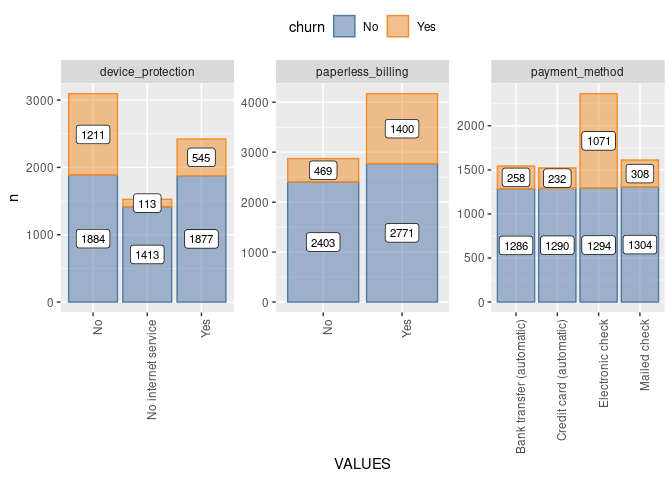

```r
# vector with the name of nominal variables to plot
vec_variable <- c("device_protection", "paperless_billing", "payment_method")

df_ibm %>%
  select(churn, one_of(vec_variable)) %>%
  select_if(is.character) %>%
  pivot_longer(names_to  = "VARIABLES",
               values_to = "VALUES",
               cols      =  one_of(vec_variable)) %>%
  count(churn, VARIABLES, VALUES) %>%
  ggplot() +
  geom_bar(position = position_stack(reverse = TRUE),
           stat = "identity",
           aes(x = VALUES, y = n, fill = churn, color = churn), alpha = 0.5) +
  theme(axis.text.x = element_text(angle = 90, hjust = 1),
        legend.position = "top") +
  facet_wrap(~ VARIABLES, ncol = 4, scales = "free") +
  scale_color_tableau() +
  scale_fill_tableau() +
  scale_x_discrete() +
  geom_label(aes(x = VALUES, y = n, label = n),
            position = position_stack(vjust = 0.5),
            size = 3)
```

```r
rm(vec_variable)
```

- Device Protection: Higher churn rate if no device protection
- Paperless Billing: Higher churn rate if paperless billing
- Payment Method: Highest churn rate with electronic check

### 4.3.6 Dependents

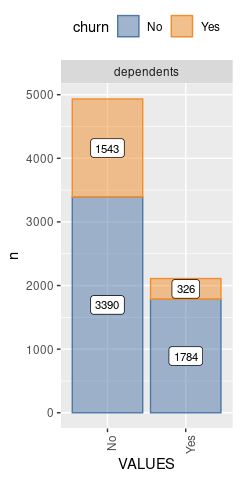

```r
# vector with the name of nominal variables to plot
vec_variable <- c("dependents")

df_ibm %>%
  select(churn, one_of(vec_variable)) %>%
  select_if(is.character) %>%
  pivot_longer(names_to  = "VARIABLES",
               values_to = "VALUES",
               cols      =  one_of(vec_variable)) %>%
  count(churn, VARIABLES, VALUES) %>%
  ggplot() +
  geom_bar(position = position_stack(reverse = TRUE),
           stat = "identity",
           aes(x = VALUES, y = n, fill = churn, color = churn), alpha = 0.5) +
  theme(axis.text.x = element_text(angle = 90, hjust = 1),
        legend.position = "top") +
  facet_wrap(~ VARIABLES, ncol = 4, scales = "free") +
  scale_color_tableau() +
  scale_fill_tableau() +
  scale_x_discrete() +
  geom_label(aes(x = VALUES, y = n, label = n),
            position = position_stack(vjust = 0.5),
            size = 3)
```

```r
rm(vec_variable)
```

- Dependents: customer with dependents have lower churn rate

## 4.4 Continuous Variables

### 4.4.1 Distributions

Distributions of continious variables: * Monthly charges * Total charges * Tenure

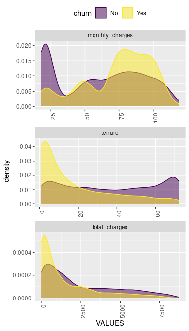

```r
df_ibm %>%
  drop_na %>%
  select(churn, monthly_charges, total_charges, tenure) %>%
  pivot_longer(names_to  = "VARIABLES",
               values_to = "VALUES",
               cols      = 2:4) %>%
  ggplot() +
  geom_density(aes(x = VALUES, fill = churn, color = churn), alpha = 0.5) +
  theme(axis.text.x = element_text(angle = 90, hjust = 1),
        legend.position = "top") +
  facet_wrap( ~ VARIABLES, nrow = 3, scales = "free") +
  scale_color_viridis(discrete = TRUE) +
  scale_fill_viridis(discrete = TRUE) +
  scale_x_continuous()
```

- Monthly Charges: A lot of current customers with less than 25$ monthly charges. For the rest, the distribution is similar.
- Total Charges: The distribution of total charges is right skewed no matter whether they churned or not.
- Tenure: Right skewed distribution for customers which have churned. Most loyal customers are either under 12 months or over 60 months.

Important: We have to log-transform the right skewed variables.

### 4.4.2 Total Charges

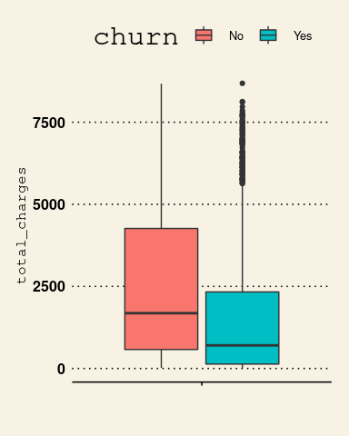

```r
df_ibm %>%
  drop_na() %>%
  ggplot() +
  geom_boxplot(aes(y = total_charges, x = "", fill = churn)) +
  theme_wsj() + xlab("") +
  theme(axis.title = element_text (size = 12))
```

- the median of total charges of customers who have churned is low.
- several outliers can be found on the upper end of churned clients with high total charges

### 4.4.3 Monthly Charges

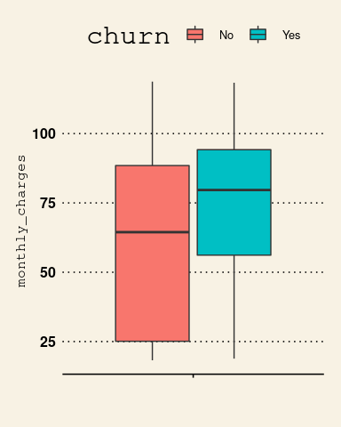

```r
df_ibm %>%
  drop_na() %>%
  ggplot() +
  geom_boxplot(aes(y = monthly_charges, x = "", fill = churn)) +
  theme_wsj() + xlab("") +
  theme(axis.title = element_text (size = 12))
```

### 4.4.4 Tenure

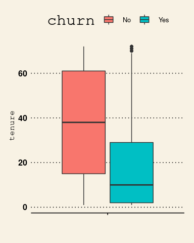

```r
df_ibm %>%
  drop_na() %>%
  ggplot() +
  geom_boxplot(aes(y = tenure, x = "", fill = churn)) +
  theme_wsj() + xlab("") +
  theme(axis.title = element_text (size = 12))
```

- Median Tenure for customer who have left is around 10 months.
- 50% of the churns occur between 3 and 30 months of tenure

## 4.5 Correlation

Checking the correlation between continuous variables

```r
df_ibm %>%
  select_if(is.numeric) %>%
  drop_na() %>%
  correlate()
```

| rowname | tenure | monthly_charges | total_charges |
| --- | --- | --- | --- |
| tenure | NA | 0.2469 | 0.8259 |
| monthly_charges | 0.2469 | NA | 0.6511 |
| total_charges | 0.8259 | 0.6511 | NA |

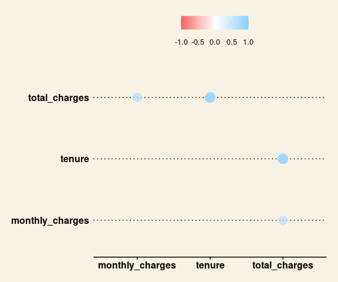

```r
df_ibm %>%
  select_if(is.numeric) %>%
  drop_na() %>%
  correlate() %>%
  rplot() +
  theme_wsj()
```

Total Charges has a positive correlation with tenure (which makes sense) and monthly charges.

# 5 Modelling

In the following chapter we will apply the classification models from the lecture. In order to do so following steps have to be taken beforehand: * Splitting the data into train and validation set * Omit Unique Values (Customer ID) * Drop NAs * log transformation * Creating dummy variables * center & scale data –> normalize

## 5.4 Cross-Validation

```r
df_cv_training <- df_01_training %>% vfold_cv(v = 5)
df_cv_training[[1]]
```

```
$`1`
<Training/Validation/Total>
<4508/1127/5635>

$`2`
<Training/Validation/Total>
<4508/1127/5635>

$`3`
<Training/Validation/Total>
<4508/1127/5635>

$`4`
<Training/Validation/Total>
<4508/1127/5635>

$`5`
<Training/Validation/Total>
<4508/1127/5635>
```

```r
# extract analysis and assessement dataset
df_cv_training_unnest <- df_cv_training %>%
  mutate(df_analysis  = map(splits, analysis),
         df_assesment = map(splits, assessment))
```

- cross validation was achieved with a five-fold cross validation
- for the following step, we change the split portions to its respective naming convention (training=analysis, assesment = testing)
- create cross-validation datasets into analysis & assessment datasets

## 5.5 Model Training

The model is trained on the crossvalided dataset, in our case with the analysis-data for 5 times. For every split iteration 4/5 are used to create the model and 1/5 to assess the model performancel. This ensures that we do not miss any crucial part of the data in order to construct the model.

## 5.6 Measure of fit

As a measure of fit when evaluating the data we are using two metrics:

- Accuracy: As our goal is to predict a binary variable we use the accuracy metric. It shows the percentage of correctly classified instances out of all instances.

Accuracy = $\frac{Number of Correct Predictions}{Total Pedictions}$

- Cohen’s Kappa: It measures the agreement between two raters and takes into account agreement occuring by chance.

Cohen’s Kappa = $\frac{p_{o}-p_{e}}{1-p_{e}}$

$p_{o}$ is the relative observed agreement among raters | $p_{e}$ is the hypothetical probability of chance agreement

## 5.7 Support Vector Machine

in the following chapter we train and evaluate support vector machine model the aim is to correctly classify the variable churn on the assessment data set

Classification SVM (radial)

### 5.7.1 Train and Predict

```r
# adjust model settings and engine parameters
model_svm <- svm_rbf(mode = "classification") %>%
  set_engine("kernlab")

svm_fit <- df_cv_training_unnest %>%
  # preprocess dataset
  mutate(recipe       = map(df_analysis, ~ prep(obj_02_recipe, training = .x)),
         df_analysis  = map(recipe, juice),
         df_assesment = map2(recipe, df_assesment, ~ bake(.x, new_data = .y))) %>%
  # fit model
  mutate(model_fit    = map(df_analysis, ~ fit(model_svm, churn ~ ., data = .x))) %>%
  # predict
  mutate(model_pred   = map2(model_fit, df_assesment, ~ predict(.x, new_data = .y)))
```

### 5.7.2 Evaluation

- in the following chapter we evaluate the performance of the support vector machine model
- the aim is to correctly classify the variable churn on the assessment data set

```r
df_svm <- svm_fit %>% select(id, df_assesment, model_pred) %>%
  mutate(df_compare = map2(df_assesment,
                        model_pred, ~ tibble(churn = .x$churn,
                                             pred  = .y$.pred_class))) %>%
  select(id, df_compare) %>%
  unnest(df_compare) %>%
  group_by(id)

df_svm %>%
  group_by(id) %>%
  conf_mat(truth = churn, estimate = pred) %>%
  mutate(summary_tbl = map(conf_mat, summary)) %>%
  unnest(summary_tbl) %>%
  select(id, .metric, .estimate) %>%
  pivot_wider(names_from = id, values_from = .estimate)
```

| .metric | Fold1 | Fold2 | Fold3 | Fold4 | Fold5 |
| --- | --- | --- | --- | --- | --- |
| accuracy | 0.8082 | 0.8044 | 0.8080 | 0.8059 | 0.7771 |
| kap | 0.4570 | 0.4323 | 0.4525 | 0.4300 | 0.3842 |
| sens | 0.9017 | 0.9188 | 0.9228 | 0.9510 | 0.9169 |
| spec | 0.5284 | 0.4722 | 0.4865 | 0.4183 | 0.4250 |
| ppv | 0.8512 | 0.8350 | 0.8342 | 0.8136 | 0.8007 |
| npv | 0.6422 | 0.6667 | 0.6923 | 0.7619 | 0.6700 |
| mcc | 0.4607 | 0.4429 | 0.4642 | 0.4610 | 0.4011 |
| j_index | 0.4300 | 0.3910 | 0.4093 | 0.3693 | 0.3419 |
| bal_accuracy | 0.7150 | 0.6955 | 0.7046 | 0.6847 | 0.6709 |
| detection_prevalence | 0.7940 | 0.8187 | 0.8151 | 0.8504 | 0.8197 |

[output cut: 3 more lines]

Lets create a Confusion Matrix in order to see how our trained model performs on the test data.

### 5.7.3 Confusion Matrix

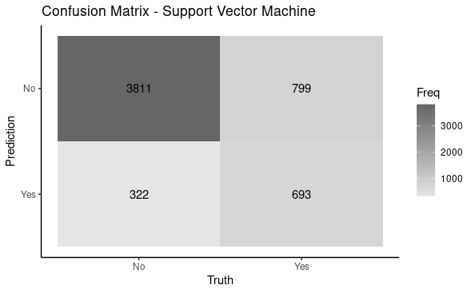

```r
df_svm %>%
  ungroup() %>%
  conf_mat(truth = churn, estimate = pred) %>% autoplot(type = "heatmap") + theme_classic() + ggtitle("Confusion Matrix - Support Vector Machine")
```

- The confusion matrix shows that around ~80% of the data points were correctly predicted.
- However around ~20% of predictions were wrong.

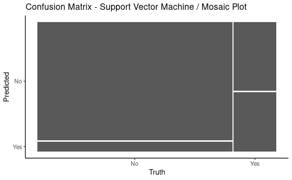

```r
df_svm %>%
  ungroup() %>% conf_mat(truth = churn, estimate = pred) %>% autoplot(type = "mosaic") + theme_classic() + ggtitle("Confusion Matrix - Support Vector Machine / Mosaic Plot")
```

## 5.8 Random Forest

- in the following chapter we train and evaluate the random forest model
- the aim is to correctly classify the variable churn on the assessment data set

### 5.8.1 Train and Predict

```r
model_randomforest <- rand_forest(mode  = "classification",
                                  mtry  = 5,
                                  trees = 3) %>%
  set_engine("randomForest") %>%
  translate()

rf_fit <- df_cv_training_unnest %>%
  # preprocess dataset
  mutate(recipe       = map(df_analysis, ~ prep(obj_02_recipe, training = .x)),
         df_analysis  = map(recipe, juice),
         df_assesment = map2(recipe, df_assesment, ~ bake(.x, new_data = .y))) %>%
  # fit model
  mutate(model_fit    = map(df_analysis, ~ fit(model_randomforest, churn ~ ., data = .x))) %>%
# predict
  mutate(model_pred   = map2(model_fit, df_assesment, ~ predict(.x, new_data = .y)))
```

### 5.8.2 Evaluation

```r
df_rf <- rf_fit %>% select(id, df_assesment, model_pred) %>%
  mutate(df_compare = map2(df_assesment, model_pred, ~ tibble(churn = .x$churn,
                                                              pred  = .y$.pred_class))) %>%
  select(id, df_compare) %>%
  unnest(df_compare) %>%
  group_by(id)

df_rf %>%
  group_by(id) %>%
  conf_mat(truth = churn, estimate = pred) %>%
  mutate(summary_tbl = map(conf_mat, summary)) %>%
  unnest(summary_tbl) %>%
  select(id, .metric, .estimate) %>%
  pivot_wider(names_from = id, values_from = .estimate)
```

| .metric | Fold1 | Fold2 | Fold3 | Fold4 | Fold5 |
| --- | --- | --- | --- | --- | --- |
| accuracy | 0.7664 | 0.7707 | 0.7787 | 0.7667 | 0.7513 |
| kap | 0.3801 | 0.3662 | 0.4012 | 0.3563 | 0.3535 |
| sens | 0.8424 | 0.8722 | 0.8758 | 0.8911 | 0.8623 |
| spec | 0.5390 | 0.4757 | 0.5068 | 0.4346 | 0.4719 |
| ppv | 0.8454 | 0.8286 | 0.8326 | 0.8080 | 0.8044 |
| npv | 0.5333 | 0.5615 | 0.5929 | 0.5991 | 0.5763 |
| mcc | 0.3801 | 0.3684 | 0.4034 | 0.3641 | 0.3567 |
| j_index | 0.3814 | 0.3479 | 0.3825 | 0.3257 | 0.3342 |
| bal_accuracy | 0.6907 | 0.6739 | 0.6913 | 0.6629 | 0.6671 |
| detection_prevalence | 0.7469 | 0.7831 | 0.7751 | 0.8023 | 0.7673 |

[output cut: 3 more lines]

### 5.8.3 Confusion Matrix

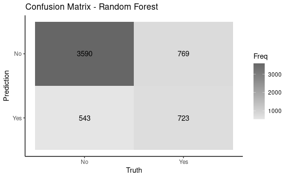

```r
df_rf %>%
  ungroup() %>% conf_mat(truth = churn, estimate = pred) %>% autoplot(type = "heatmap") + theme_classic() + ggtitle("Confusion Matrix - Random Forest")
```

- The confusion matrix shows that around ~77% of the data points were correctly predicted.
- However around ~23% of the predictions were wrong. This is hence a worse prediction score than with the SVM model.

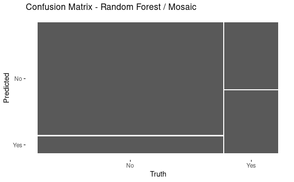

```r
df_rf %>%
  ungroup() %>% conf_mat(truth = churn, estimate = pred) %>% autoplot(type = "mosaic") + ggtitle("Confusion Matrix - Random Forest / Mosaic")
```

- the same confusion matrix as above can be drawn with weighted tiles
- as seen with the svm confusion matrix, the model struggles more with the prediction for a churned client
- overall, the amount of flase predictions is higher

## 5.9 Logistic Regression

- in the following chapter we train and evaluate the logistic regression model
- the aim is to correctly classify the variable churn on the assessment data set

### 5.9.1 Train and Predict

```r
model_logistic <- logistic_reg(mode = "classification") %>%
  set_engine("glm")

log_fit <- df_cv_training_unnest %>%
  # preprocess dataset
  mutate(recipe       = map(df_analysis, ~ prep(obj_02_recipe, training = .x)),
         df_analysis  = map(recipe, juice),
         df_assesment = map2(recipe, df_assesment, ~ bake(.x, new_data = .y))) %>%
  # fit model
  mutate(model_fit    = map(df_analysis, ~ fit(model_logistic, churn ~ ., data = .x))) %>%
# predict
  mutate(model_pred   = map2(model_fit, df_assesment, ~ predict(.x, new_data = .y)))
```

### 5.9.2 Evaluation

```r
df_log <- log_fit %>% select(id, df_assesment, model_pred) %>%
  mutate(df_compare = map2(df_assesment, model_pred, ~ tibble(churn = .x$churn,
                                                              pred  = .y$.pred_class))) %>%
  select(id, df_compare) %>%
  unnest(df_compare) %>%
  group_by(id)

df_log %>%
  group_by(id) %>%
  conf_mat(truth = churn, estimate = pred) %>%
  mutate(summary_tbl = map(conf_mat, summary)) %>%
  unnest(summary_tbl) %>%
  select(id, .metric, .estimate) %>%
  pivot_wider(names_from = id, values_from = .estimate)
```

| .metric | Fold1 | Fold2 | Fold3 | Fold4 | Fold5 |
| --- | --- | --- | --- | --- | --- |
| accuracy | 0.8073 | 0.8124 | 0.8098 | 0.8219 | 0.7842 |
| kap | 0.4711 | 0.4709 | 0.4703 | 0.4997 | 0.4315 |
| sens | 0.8863 | 0.9104 | 0.9119 | 0.9388 | 0.8933 |
| spec | 0.5709 | 0.5278 | 0.5236 | 0.5098 | 0.5094 |
| ppv | 0.8608 | 0.8486 | 0.8428 | 0.8364 | 0.8210 |
| npv | 0.6265 | 0.6696 | 0.6798 | 0.7573 | 0.6546 |
| mcc | 0.4720 | 0.4765 | 0.4771 | 0.5161 | 0.4376 |
| j_index | 0.4572 | 0.4382 | 0.4356 | 0.4486 | 0.4027 |
| bal_accuracy | 0.7286 | 0.7191 | 0.7178 | 0.7243 | 0.7013 |
| detection_prevalence | 0.7718 | 0.7982 | 0.7973 | 0.8166 | 0.7789 |

[output cut: 3 more lines]

```r
NA
```

### 5.9.3 Confusion Matrix

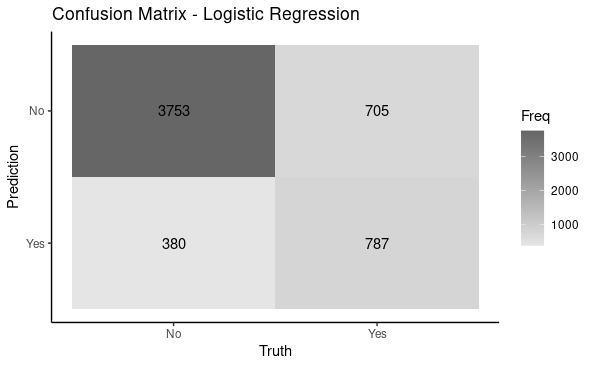

```r
df_log %>%
  ungroup() %>% conf_mat(truth = churn, estimate = pred) %>% autoplot(type = "heatmap") + theme_classic() + ggtitle("Confusion Matrix - Logistic Regression")
```

- The confusion matrix shows that around ~80% of the data points were correctly predicted.
- However around ~20% of the predictions were wrong.
- So far, the logistic regression model performed the best

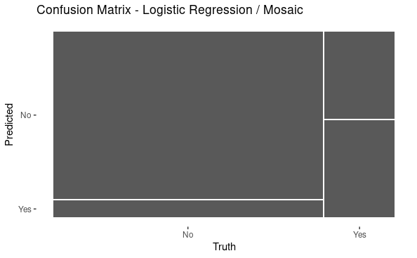

```r
df_log %>%
  ungroup() %>% conf_mat(truth = churn, estimate = pred) %>% autoplot(type = "mosaic") + ggtitle("Confusion Matrix - Logistic Regression / Mosaic")
```

- the classifications get better, the error distribution stays the same as seen above.

## 5.10 Artificial Neural Networks

- in the following chapter we train and evaluate the classification through neural networks algorithm.

### 5.10.1 Train and Predict

```r
model_neural <- mlp(mode = "classification",
                    hidden_units = 3,
                    penalty = 0,
                    activation = "linear",
                    epochs = 6) %>%
  set_engine("keras")


neural_fit <- df_cv_training_unnest %>%
  # preprocess dataset
  mutate(recipe       = map(df_analysis, ~ prep(obj_02_recipe, training = .x)),
         df_analysis  = map(recipe, juice),
         df_assesment = map2(recipe, df_assesment, ~ bake(.x, new_data = .y))) %>%
  # fit model
  mutate(model_fit    = map(df_analysis, ~ fit(model_neural, churn ~ ., data = .x))) %>%
# predict
  mutate(model_pred   = map2(model_fit, df_assesment, ~ predict(.x, new_data = .y)))
```

### 5.10.2 Evaluation

```r
df_neural <- neural_fit %>% select(id, df_assesment, model_pred) %>%
  mutate(df_compare = map2(df_assesment, model_pred, ~ tibble(churn = .x$churn,
                                                              pred  = .y$.pred_class))) %>%
  select(id, df_compare) %>%
  unnest(df_compare) %>%
  group_by(id)

df_neural %>%
  group_by(id) %>%
  conf_mat(truth = churn, estimate = pred) %>%
  mutate(summary_tbl = map(conf_mat, summary)) %>%
  unnest(summary_tbl) %>%
  select(id, .metric, .estimate) %>%
  pivot_wider(names_from = id, values_from = .estimate)
```

| .metric | Fold1 | Fold2 | Fold3 | Fold4 | Fold5 |
| --- | --- | --- | --- | --- | --- |
| accuracy | 0.8002 | 0.8009 | 0.8151 | 0.8201 | 0.7771 |
| kap | 0.4633 | 0.4444 | 0.4923 | 0.4935 | 0.4164 |
| sens | 0.8709 | 0.8973 | 0.9083 | 0.9388 | 0.8846 |
| spec | 0.5887 | 0.5208 | 0.5541 | 0.5033 | 0.5062 |
| ppv | 0.8637 | 0.8448 | 0.8508 | 0.8346 | 0.8186 |
| npv | 0.6036 | 0.6356 | 0.6833 | 0.7549 | 0.6353 |
| mcc | 0.4634 | 0.4481 | 0.4970 | 0.5105 | 0.4212 |
| j_index | 0.4595 | 0.4181 | 0.4624 | 0.4421 | 0.3909 |
| bal_accuracy | 0.7298 | 0.7090 | 0.7312 | 0.7210 | 0.6954 |
| detection_prevalence | 0.7558 | 0.7902 | 0.7867 | 0.8183 | 0.7735 |

[output cut: 3 more lines]

```r
NA
```

### 5.10.3 Confusion Matrix

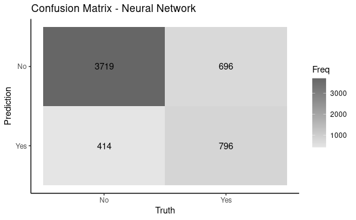

```r
df_neural %>%
  ungroup() %>% conf_mat(truth = churn, estimate = pred) %>% autoplot(type = "heatmap") + theme_classic() + ggtitle("Confusion Matrix - Neural Network")
```

- The confusion matrix shows that around ~80% of the data points were correctly predicted.
- However around ~20% predictions were wrong.

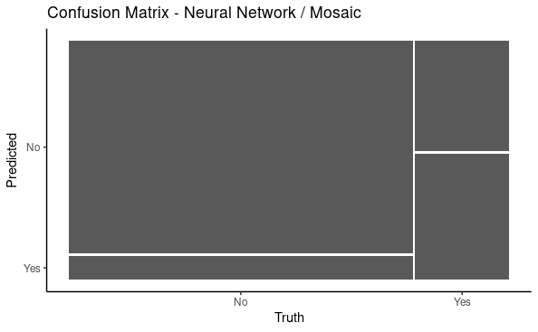

```r
df_neural %>%
  ungroup() %>% conf_mat(truth = churn, estimate = pred) %>% autoplot(type = "mosaic") + theme_classic() + ggtitle("Confusion Matrix - Neural Network / Mosaic")
```

- same distribution as seen before
- feature engineering is needed to get the model a better understanding for churned clients

## 5.11 Model Assessments

Taking a short recap we see how the models performed so far.

Wrong predictions made:

- ~20% artificial neural networks
- ~20% logistic regression
- ~20% support vector machines
- ~23% random forest

## 5.12 Model Comparison

- with the short recap from above in mind, we would like to compare the outcome numerically
- with the following lines of code, we fit again each of the above models and let them compete against each other
- after the fit, the column *predict* is being extracted to later visualize for a better understanding
- we evaluate the model performance with the testing dataset

```r
recipe_classification <-
  recipe(churn ~ ., data = df_01_training) %>%
    step_naomit(all_predictors()) %>%
    step_log(total_charges) %>%
    step_log(monthly_charges) %>%
    step_dummy (all_nominal(),    -all_outcomes()) %>%
    step_center(all_predictors(), -all_outcomes()) %>%
    step_scale (all_predictors(), -all_outcomes()) %>%
  prep()

df_cl_train_pp <- bake(recipe_classification, new_data = df_01_training)
df_cl_test_pp  <- bake(recipe_classification, new_data = df_01_testing)


fit_svm <- model_svm %>% fit(churn ~ ., data = df_cl_train_pp)
fit_rf  <- model_randomforest %>% fit(churn ~ ., data = df_cl_train_pp)
fit_log <- model_logistic %>% fit(churn ~ ., data = df_cl_train_pp)
fit_nn  <- model_neural %>% fit(churn ~ ., data = df_cl_train_pp)


df_cl_predict <-
  df_cl_test_pp %>%
  mutate("SVM_" = fit_svm %>% predict(new_data = df_cl_test_pp) %>% pull,
         "RF__" = fit_rf  %>% predict(new_data = df_cl_test_pp) %>% pull,
         "LOG_" = fit_log %>% predict(new_data = df_cl_test_pp) %>% pull,
         "NNET" = fit_nn  %>% predict(new_data = df_cl_test_pp) %>% pull)
```

```r
df_eval <-  df_cl_predict %>% conf_mat(truth = churn, estimate = SVM_) %>% summary %>% mutate(model = "SVM_")  %>%
  bind_rows(df_cl_predict %>% conf_mat(truth = churn, estimate = RF__) %>% summary %>% mutate(model = "RF__")) %>%
  bind_rows(df_cl_predict %>% conf_mat(truth = churn, estimate = LOG_) %>% summary %>% mutate(model = "LOG_")) %>%
  bind_rows(df_cl_predict %>% conf_mat(truth = churn, estimate = NNET) %>% summary %>% mutate(model = "NNET"))

df_eval %>%
  select(-.estimator) %>%
  pivot_wider(names_from = model, values_from = .estimate)
```

| .metric | SVM_ | RF__ | LOG_ | NNET |
| --- | --- | --- | --- | --- |
| accuracy | 0.8017 | 0.7775 | 0.8060 | 0.8131 |
| kap | 0.4309 | 0.4054 | 0.4635 | 0.4831 |
| sens | 0.9291 | 0.8748 | 0.9126 | 0.9175 |
| spec | 0.4536 | 0.5119 | 0.5146 | 0.5279 |
| ppv | 0.8229 | 0.8304 | 0.8370 | 0.8415 |
| npv | 0.7008 | 0.5994 | 0.6831 | 0.7007 |
| mcc | 0.4477 | 0.4077 | 0.4714 | 0.4914 |
| j_index | 0.3827 | 0.3867 | 0.4272 | 0.4453 |
| bal_accuracy | 0.6914 | 0.6933 | 0.7136 | 0.7227 |
| detection_prevalence | 0.8266 | 0.7711 | 0.7982 | 0.7982 |

[output cut: 3 more lines]

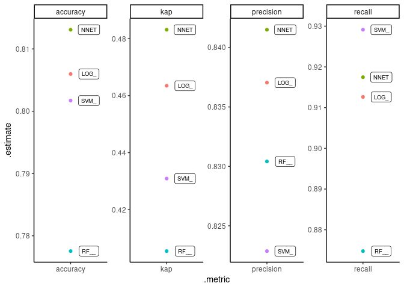

```r
vec_metrics <- c("accuracy", "kap", "precision", "recall") # "precision", "recall"

df_eval %>%
  filter(.metric %in% vec_metrics) %>%
  ggplot() +
  geom_point(aes(x = .metric, y = .estimate, col = model)) +
  facet_wrap(.metric ~ ., scales = "free", ncol = 4) +
  theme(strip.background = element_blank(), strip.text.x = element_blank()) +
  geom_label(aes(x = .metric, y = .estimate, label = model), nudge_x = 0.3, size = 2.5 ) +
  theme_classic() +
  theme(legend.position = "None")
```

$$Accuracy = \frac{\text{Number of correct predictions}}{\text{Total number of predictions made}}$$

- There are many cases in which classification accuracy is not a good indicator for the model performance. One of these scenarios is when the class distribution is imbalanced (one class is more frequent than others). This is actually the case in our data set. So we do have a higher amount of non churned customers. This being taken in account, the predictions get more accurate.

$$Precision = \frac{\text{True Positive}}{\text{True Positive + False Positive}}$$

# 6 Conclusion

All models have performed not so well in predicting the customers who actually churned in comparison to those who did not churn (NON-Churners). In a next step it would be advisable to do feature engineering increase the prediction-accuracy of the churned customers. Another approach would be to retrain the models with balanced datasets. A possible way to do this would be to downsample NON-Churners before training the models.

All in all, there are only minor differences in the performance of the classification models. However the algorithms can be optimized by using hyperparameter-tuning and grid search.